# How to Data Science with Weather

This data science pipeline tutorial will be using weather event data from [here[1]](https://www.kaggle.com/sobhanmoosavi/us-weather-events/version/1).This dataset contains the type, time, and location of recorded weather events in 49 US states from 2016 and 2019. After downloading the dataset in your working directory, the following code will allow you to use it in R. You can find the Federal Aviation Administration’s airport weather station locations and data [here[2]](https://www.faa.gov/air_traffic/weather/asos/).

```r
library(tidyverse)
library(broom)
library(lubridate)
library(randomForest)
set.seed(0518)
# loading code goes here
weather_tab <- read_csv( file = "US_WeatherEvents_2016-2019.csv" )
# display dataframe
weather_tab
```

```
## # A tibble: 5,059,833 x 13
##    EventId Type  Severity `StartTime(UTC)`    `EndTime(UTC)`      TimeZone
##    <chr>   <chr> <chr>    <dttm>              <dttm>              <chr>
##  1 W-1     Snow  Light    2016-01-06 23:14:00 2016-01-07 00:34:00 US/Moun~
##  2 W-2     Snow  Light    2016-01-07 04:14:00 2016-01-07 04:54:00 US/Moun~
##  3 W-3     Snow  Light    2016-01-07 05:54:00 2016-01-07 15:34:00 US/Moun~
##  4 W-4     Snow  Light    2016-01-08 05:34:00 2016-01-08 05:54:00 US/Moun~
##  5 W-5     Snow  Light    2016-01-08 13:54:00 2016-01-08 15:54:00 US/Moun~
##  6 W-6     Snow  Light    2016-01-08 16:14:00 2016-01-08 17:34:00 US/Moun~
##  7 W-7     Fog   Severe   2016-01-09 12:54:00 2016-01-09 15:34:00 US/Moun~
##  8 W-8     Snow  Light    2016-01-09 15:34:00 2016-01-09 16:14:00 US/Moun~
##  9 W-9     Fog   Severe   2016-01-09 16:14:00 2016-01-09 16:34:00 US/Moun~
## 10 W-10    Snow  Light    2016-01-09 16:34:00 2016-01-09 16:54:00 US/Moun~
## # ... with 5,059,823 more rows, and 7 more variables: AirportCode <chr>,
## #   LocationLat <dbl>, LocationLng <dbl>, City <chr>, County <chr>,
## #   State <chr>, ZipCode <dbl>
```

As you can see the dataset contains 5,059,833 entities ( weather events ) and 13 attributes. EventId: Identifier for event | Data Type | no transformation required

Type: Weather type of event | Data Type | As an unordered categorical attribute we will want to transform into R factor [ Snow, Fog, Cold, Storm, Rain, Precipitation, Hail ]

Severity: Severity of event | Data Type | As an ordered categorical attribute we will want to transform into R factor, additionally removing UNK and Other classifications should make order more clear [ Light, Moderate, Heavy, Severe, UNK, Other ]

StartTime(UTC): Datetime of event start in UTC | Data Type <S3: POSIXct> (datetime) | we will remove “(UTC)” to avoid being mistaken for a function

EndTime(UTC): Datetime of event end in UTC | Data Type <S3: POSIXct> (datetime) | we will remove “(UTC)” to avoid being mistaken for a function

TimeZone: US time zone of event | Data Type | As an unordered categorical attribute we will want to transform into R factor

AirportCode: Airport weather station that reported event | Data Type | no transformation required

LocationLat: Latitude of reporting airport weather station | Data Type | no transformation required

LocationLng: Latitude of reporting airport weather station | Data Type | no transformation required

City: City of reporting airport weather station | Data Type | no transformation required

County: County of reporting airport weather station | Data Type | no transformation required

State: State of reporting airport weather station | Data Type | no transformation required

Zipcode: Zip code of reporting airport weather station | Data Type | no transformation required

We will now perform some operations to improve data usability.

```r
# Perform data transformations to improve usability of weather data
transformed_weather_tab <- weather_tab %>%
  # remove events with unknown or other severity classifcation
  filter( Severity != "UNK" & Severity != "Other" ) %>%
  # factorize Type, Severity, and Timezone
  mutate( Type = as.factor( Type ), Severity = factor( x = Severity, levels = c( "Light", "Moderate", "Heavy", "Severe" ) ), TimeZone = as.factor( TimeZone ) ) %>%
  # rename datetimes
  mutate( StartTime = `StartTime(UTC)`, EndTime = `EndTime(UTC)` ) %>%
  select( -`StartTime(UTC)`, -`EndTime(UTC)` )
# display
transformed_weather_tab
```

```
## # A tibble: 4,990,020 x 13
##    EventId Type  Severity TimeZone AirportCode LocationLat LocationLng City
##    <chr>   <fct> <fct>    <fct>    <chr>             <dbl>       <dbl> <chr>
##  1 W-1     Snow  Light    US/Moun~ K04V               38.1       -106. Sagu~
##  2 W-2     Snow  Light    US/Moun~ K04V               38.1       -106. Sagu~
##  3 W-3     Snow  Light    US/Moun~ K04V               38.1       -106. Sagu~
##  4 W-4     Snow  Light    US/Moun~ K04V               38.1       -106. Sagu~
##  5 W-5     Snow  Light    US/Moun~ K04V               38.1       -106. Sagu~
##  6 W-6     Snow  Light    US/Moun~ K04V               38.1       -106. Sagu~
##  7 W-7     Fog   Severe   US/Moun~ K04V               38.1       -106. Sagu~
##  8 W-8     Snow  Light    US/Moun~ K04V               38.1       -106. Sagu~
##  9 W-9     Fog   Severe   US/Moun~ K04V               38.1       -106. Sagu~
## 10 W-10    Snow  Light    US/Moun~ K04V               38.1       -106. Sagu~
## # ... with 4,990,010 more rows, and 5 more variables: County <chr>,
## #   State <chr>, ZipCode <dbl>, StartTime <dttm>, EndTime <dttm>
```

As the address of the reporting airport weather stations are constant, we will want to tidy the data by separating the table into a weather event table and reporting weather station table.

```r
# create airport weather station table
airport_station_tab <- transformed_weather_tab %>%
  # remove non-airport information
  select( -EventId, -Type, -Severity, -StartTime, -EndTime, -TimeZone )
airport_station_tab %>%
  # only unique entities
  unique()
```

```
## # A tibble: 2,070 x 7
##    AirportCode LocationLat LocationLng City         County         State ZipCode
##    <chr>             <dbl>       <dbl> <chr>        <chr>          <chr>   <dbl>
##  1 K04V               38.1      -106.  Saguache     Saguache       CO      81149
##  2 KAXS               34.7       -99.3 Altus        Jackson        OK      73521
##  3 KAEL               43.7       -93.4 Albert Lea   Freeborn       MN      56007
##  4 KBTR               30.5       -91.1 Baton Rouge  East Baton Ro~ LA      70807
##  5 KCMY               44.0       -90.7 Sparta       Monroe         WI      54656
##  6 KDIJ               43.7      -111.  Driggs       Teton          ID      83422
##  7 KGRR               42.9       -85.5 Grand Rapids Kent           MI      49512
##  8 KHUT               38.1       -97.9 Hutchinson   Reno           KS      67501
##  9 KEMM               41.8      -111.  Kemmerer     Lincoln        WY      83101
## 10 KPSF               42.4       -73.3 Pittsfield   Berkshire      MA       1201
## # ... with 2,060 more rows
```

```r
# display
airport_station_tab
```

```
## # A tibble: 4,990,020 x 7
##    AirportCode LocationLat LocationLng City     County   State ZipCode
##    <chr>             <dbl>       <dbl> <chr>    <chr>    <chr>   <dbl>
##  1 K04V               38.1       -106. Saguache Saguache CO      81149
##  2 K04V               38.1       -106. Saguache Saguache CO      81149
##  3 K04V               38.1       -106. Saguache Saguache CO      81149
##  4 K04V               38.1       -106. Saguache Saguache CO      81149
##  5 K04V               38.1       -106. Saguache Saguache CO      81149
##  6 K04V               38.1       -106. Saguache Saguache CO      81149
##  7 K04V               38.1       -106. Saguache Saguache CO      81149
##  8 K04V               38.1       -106. Saguache Saguache CO      81149
##  9 K04V               38.1       -106. Saguache Saguache CO      81149
## 10 K04V               38.1       -106. Saguache Saguache CO      81149
## # ... with 4,990,010 more rows
```

```r
# length of unique AirportCodes is the same as the number of unqiue entities in table, Airport code can function as primary key
length( unique( airport_station_tab$AirportCode ) )
```

```
## [1] 2070
```

```r
# remove airport fields excpet AirportCode from weather table
transformed_weather_tab <- transformed_weather_tab %>%
  select( EventId, Type, Severity, StartTime, EndTime, TimeZone, AirportCode )
# display
transformed_weather_tab
```

```
## # A tibble: 4,990,020 x 7
##    EventId Type  Severity StartTime           EndTime             TimeZone
##    <chr>   <fct> <fct>    <dttm>              <dttm>              <fct>
##  1 W-1     Snow  Light    2016-01-06 23:14:00 2016-01-07 00:34:00 US/Moun~
##  2 W-2     Snow  Light    2016-01-07 04:14:00 2016-01-07 04:54:00 US/Moun~
##  3 W-3     Snow  Light    2016-01-07 05:54:00 2016-01-07 15:34:00 US/Moun~
##  4 W-4     Snow  Light    2016-01-08 05:34:00 2016-01-08 05:54:00 US/Moun~
##  5 W-5     Snow  Light    2016-01-08 13:54:00 2016-01-08 15:54:00 US/Moun~
##  6 W-6     Snow  Light    2016-01-08 16:14:00 2016-01-08 17:34:00 US/Moun~
##  7 W-7     Fog   Severe   2016-01-09 12:54:00 2016-01-09 15:34:00 US/Moun~
##  8 W-8     Snow  Light    2016-01-09 15:34:00 2016-01-09 16:14:00 US/Moun~
##  9 W-9     Fog   Severe   2016-01-09 16:14:00 2016-01-09 16:34:00 US/Moun~
## 10 W-10    Snow  Light    2016-01-09 16:34:00 2016-01-09 16:54:00 US/Moun~
## # ... with 4,990,010 more rows, and 1 more variable: AirportCode <chr>
```

Let’s look at the breakdown of weather events by type.

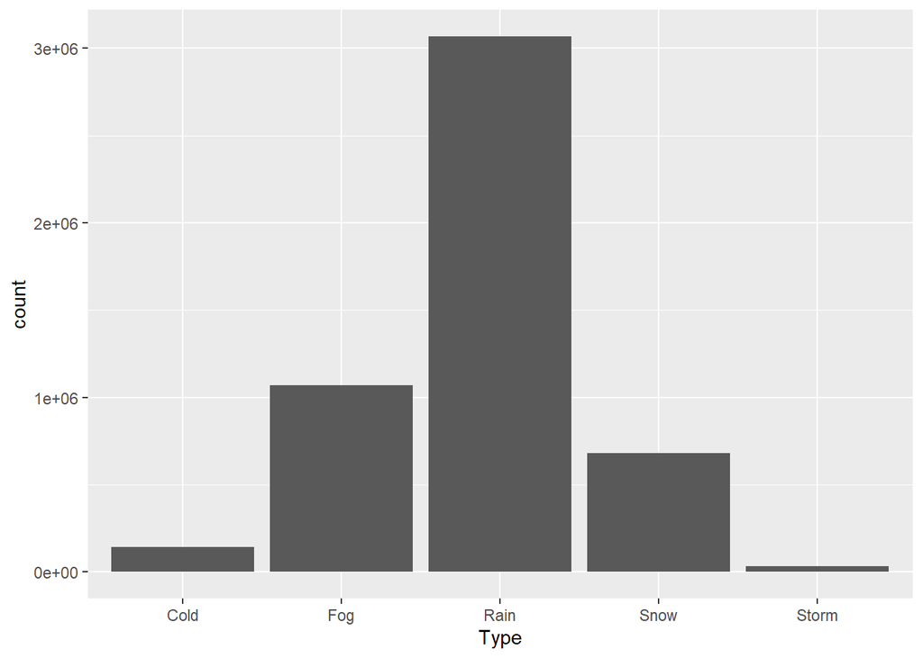

```r
# plot duration vs start datetime as scatter plot
transformed_weather_tab %>%
  # start datetime as x-axis, end datetime as y-axis
  ggplot( aes( Type ) ) +
  # scatter plot
  geom_bar()
```

We can see the rain is by far the most frequent type of weather event for the data set. What would be even more useful is if we could separate the data by month so we could comment on trends over time. This is all leading up to weather prediction which is important for saving lives and property. [National Oceanic and Atmospheric Administration’s[3]](https://www.noaa.gov/weather) website is a good place to start for those curious about the ramifications of severe weather.

```r
# break down by year
transformed_weather_tab$year <- format( transformed_weather_tab$StartTime, "%Y" )
# break down by month
transformed_weather_tab$month <- factor( format( transformed_weather_tab$StartTime, "%b" ), levels = c( "Jan", "Feb", "Mar", "Apr", "May", "Jun", "Jul", "Aug", "Sep", "Oct", "Nov", "Dec" ) )
```

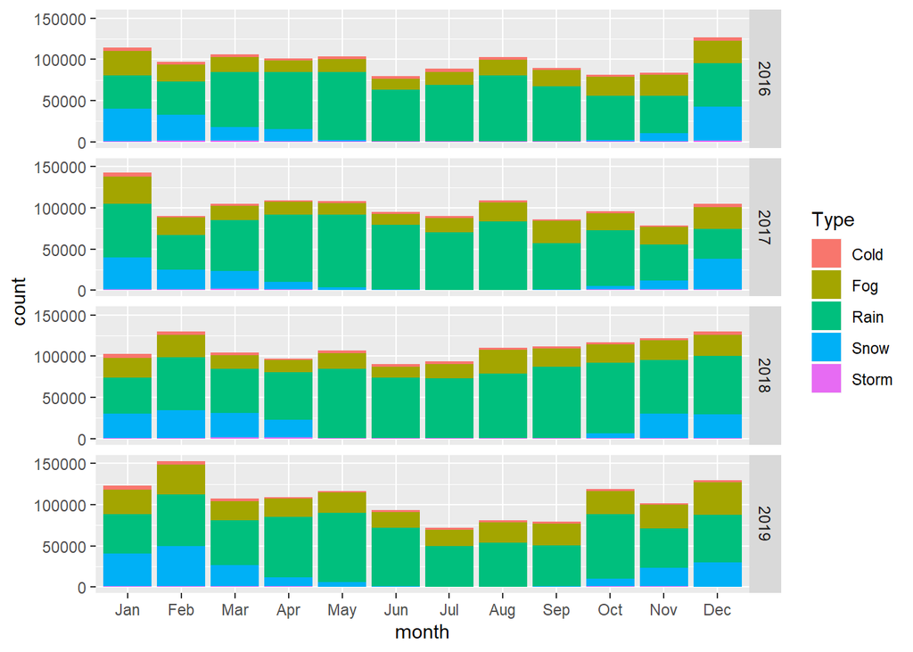

```r
# break down by year
transformed_weather_tab %>%
  # start month as x-axis, number of events on y-axis
  ggplot( aes( x = month, fill = Type ) ) +
  # break into different graphs by year
  facet_grid( year~. ) +
  # bar plot
  geom_bar( )
```

Now we can see monthly variations in the number and type of weather events recorded. In the winter, we can see that snow can be as common as rain (which makes intuitive sense), but this result was obscured when we were simply looking at the frequency over the entire data set. These sorts of visualizations help us better understand the data and give us insight into what might give useful analysis.

We will be testing a simple hypothesis. We will hypothesis and then test whether the true average duration of light rain weather events is less than 1.25 hours or slightly over our sample mean. We want to be 90% confident that we are correct. That is randomly sampling and taking the mean of those samples we would expect the sample mean to be less than 1.25 hours. That is our null hypothesis should be $H_0: \bar{X} >= 1.25$ with confidence level $\alpha = 0.1$. Before we go out testing this we will want to get a sense over whether the Central Limit Theorem (CLT) can be reasonably applied in this situation.

```r
# duration of weather event in hours
transformed_weather_tab$duration <- as.numeric( transformed_weather_tab$EndTime - transformed_weather_tab$StartTime ) / 3600

# create new data frame just for light rain
light_rain_tab <- transformed_weather_tab %>%
  filter( Type == "Rain" & Severity == "Light" )
light_rain_tab
```

```
## # A tibble: 2,540,233 x 10
##    EventId Type  Severity StartTime           EndTime             TimeZone
##    <chr>   <fct> <fct>    <dttm>              <dttm>              <fct>
##  1 W-52    Rain  Light    2016-02-19 04:34:00 2016-02-19 05:14:00 US/Moun~
##  2 W-83    Rain  Light    2016-04-09 20:55:00 2016-04-09 21:15:00 US/Moun~
##  3 W-84    Rain  Light    2016-04-09 22:55:00 2016-04-10 00:15:00 US/Moun~
##  4 W-85    Rain  Light    2016-04-11 06:15:00 2016-04-11 06:35:00 US/Moun~
##  5 W-86    Rain  Light    2016-04-11 21:55:00 2016-04-11 22:15:00 US/Moun~
##  6 W-87    Rain  Light    2016-04-12 03:55:00 2016-04-12 04:55:00 US/Moun~
##  7 W-88    Rain  Light    2016-04-12 23:15:00 2016-04-12 23:35:00 US/Moun~
##  8 W-89    Rain  Light    2016-04-12 23:55:00 2016-04-13 00:55:00 US/Moun~
##  9 W-90    Rain  Light    2016-04-13 02:35:00 2016-04-13 02:55:00 US/Moun~
## 10 W-91    Rain  Light    2016-04-15 21:55:00 2016-04-15 22:15:00 US/Moun~
## # ... with 2,540,223 more rows, and 4 more variables: AirportCode <chr>,
## #   year <chr>, month <fct>, duration <dbl>
```

```r
# mean of light rean duration in hours
light_rain_mean_duration <- mean( light_rain_tab $duration )
light_rain_mean_duration
```

```
## [1] 1.245116
```

```r
# standard deviation of light rain duration in hours
light_rain_sd_duration <- sd( light_rain_tab $duration )
light_rain_sd_duration
```

```
## [1] 5.870685
```

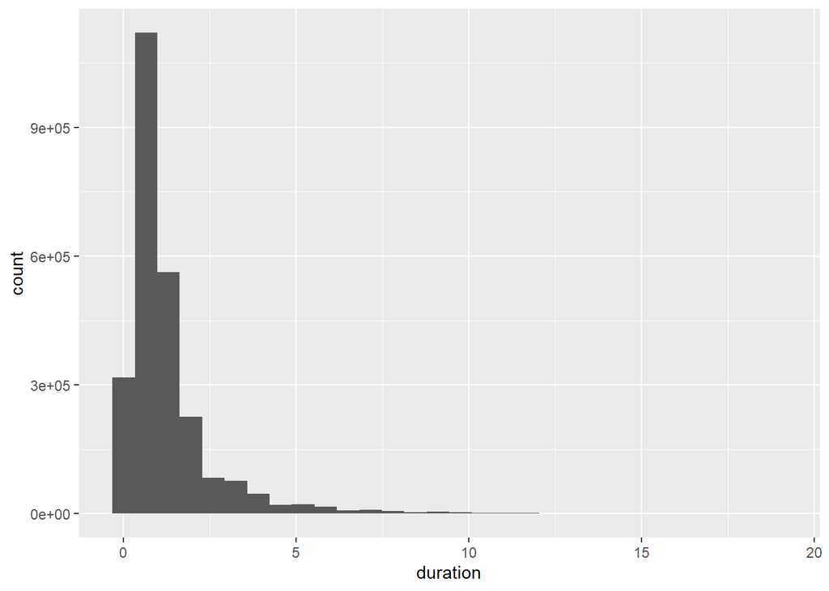

```r
# plot distribution of durations for light rain using histogram
light_rain_tab %>%
# exclude values more than three sample standard deviations from the histogram for ease of viewing
  filter( light_rain_mean_duration + 3 * light_rain_sd_duration >= duration & light_rain_mean_duration - 3 * light_rain_sd_duration <= duration) %>%
  # duration as data
  ggplot( aes( x = duration ) ) +
  # histogram with 20 bins
  geom_histogram()
```

As can be seen above there is some level of skew in duration ( durations cannot be less than 0 hr after all ), but for such a large set of data CLT can be assumed to be valid. We will than use our knowledge of the sample mean and standard deviation to approximate $P( \bar{X} >= 1.25 )$ as $1 - \phi(z)$ for $z = \frac{ 1.25-\mu }{ se(X) }$.

```r
# standard error of light rain duration in hours
light_rain_se_duration = light_rain_sd_duration / sqrt( length( light_rain_tab$duration ) )
# probability that the null hypotheses is true
1 - pnorm( 1.25, mean = light_rain_mean_duration, sd = light_rain_se_duration )
```

```
## [1] 0.09245228
```

$P( \bar{X} >= 1.25 ) <= \alpha$, so we reject the null hypothesis. We use this to confirm our original hypothesis that the mean was less than 1.25 hours.

Now we will attempt to predict an outcome. Let’s see if we can predict whether a given event will last more than one hour. First we will plot duration conditioned on several variables we believe to be promising to see whether there is any relation

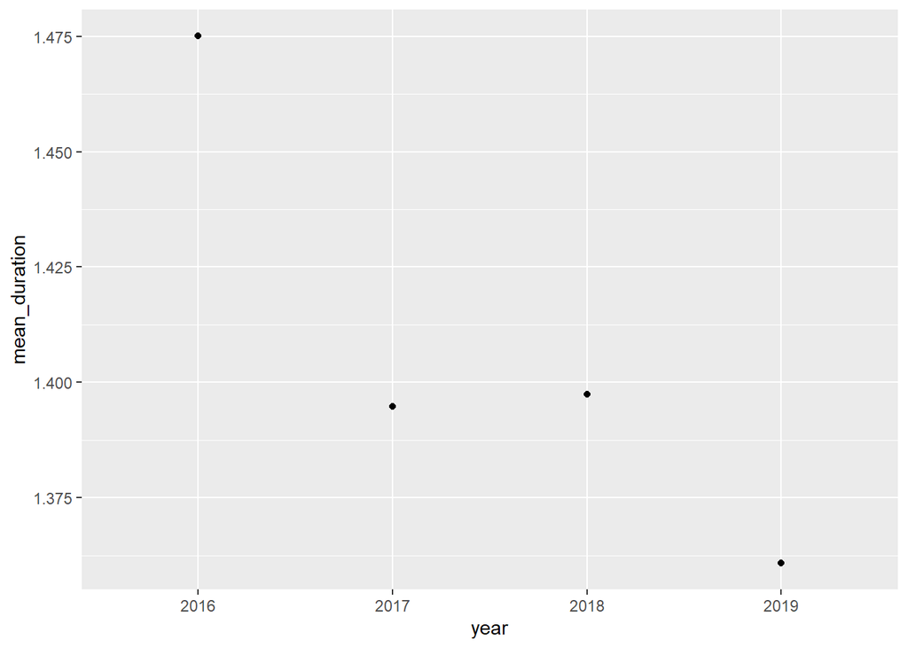

```r
# time dividing true and false
bound = 1

# whether duration greater than bound
transformed_weather_tab$overBound = transformed_weather_tab$duration > bound

# plot mean event weather duration conditioned on year
transformed_weather_tab %>%
  # condition on year
  group_by( year ) %>%
  # get mean duration
  summarize( mean_duration = mean( duration ) ) %>%
  # year on x-axis, mean duration on x-axis
  ggplot( aes( x = year, y = mean_duration ) ) +
  # scatter plot
  geom_point()
```

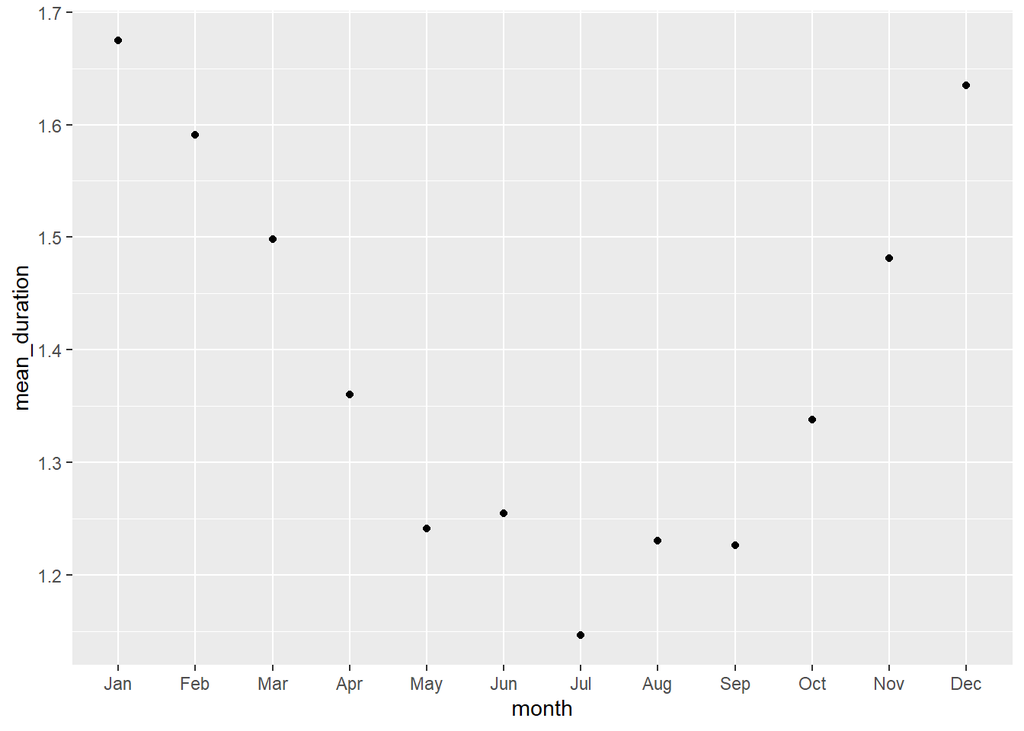

```r
# plot mean event weather duration conditioned on month
transformed_weather_tab %>%
  # condition on month
  group_by( month ) %>%
  # get mean duration
  summarize( mean_duration = mean( duration ) ) %>%
  # month on x-axis, mean duration on x-axis
  ggplot( aes( x = month, y = mean_duration ) ) +
  # scatter plot
  geom_point()
```

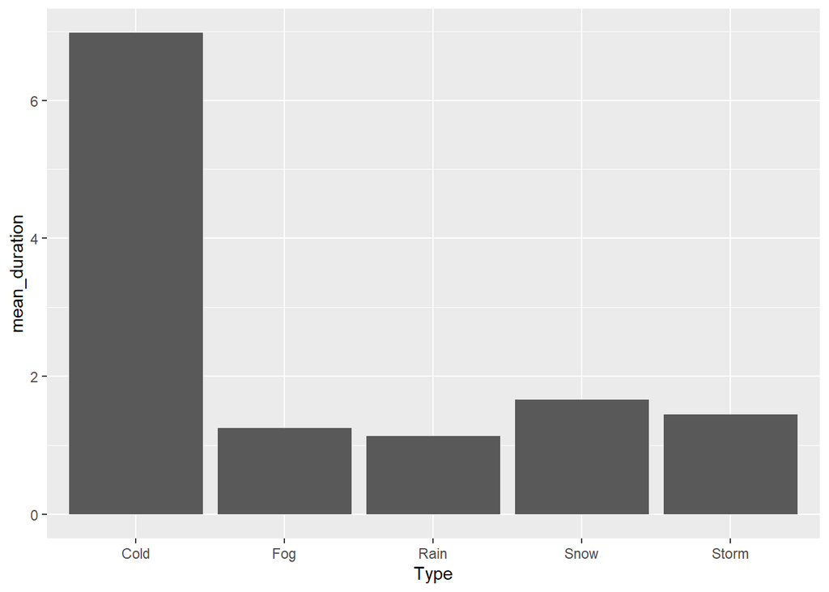

```r
# plot mean event weather duration conditioned on type
transformed_weather_tab %>%
  # condition on type
  group_by( Type ) %>%
  # get mean duration
  summarize( mean_duration = mean( duration ) ) %>%
  # type on x-axis, duration on x-axis
  ggplot( aes( x = Type, y = mean_duration ) ) +
  # bar plot
  geom_bar( stat = "identity")
```

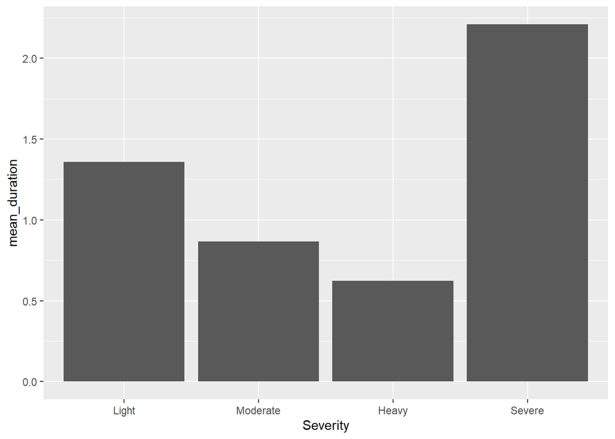

```r
# plot mean event weather duration conditioned on severity
transformed_weather_tab %>%
  # condition on month
  group_by( Severity ) %>%
  # get mean duration
  summarize( mean_duration = mean( duration ) ) %>%
  # month on x-axis, mean duration on x-axis
  ggplot( aes( x = Severity, y = mean_duration ) ) +
  # bar plot
  geom_bar( stat = "identity")
```

We can see that for year, month, type, and severity there is some sort of relation between these values and duration. Unfortunately this does not seem to be linear relation, so we will attempt to create a random forest to predict whether the duration for a given event will exceed 1 hour.

```r
# randomly determine indices of training set
train_indices <- sample(nrow(transformed_weather_tab), nrow(transformed_weather_tab)/1E3 )
# traing set we will use to make model
train_set <- transformed_weather_tab[train_indices,]
# testing set which we will use to judge the predictive capabilities of the model
test_set <- transformed_weather_tab[-train_indices,]

# create a random forest using year, month, type, and severity to predict whether an event will last longer than 1 hour
weather_rf <- randomForest( overBound~year+month+Type+Severity, importance=TRUE, mtry=4, data=train_set)

# view importance of variables in creating random forest forest
variable_importance <- importance(weather_rf)
knitr::kable(head(round(variable_importance, digits=2)))
```

|  | %IncMSE | IncNodePurity |
| --- | --- | --- |
| year | 24.41 | 32.06 |
| month | 42.41 | 55.35 |
| Type | 36.27 | 23.61 |
| Severity | 64.65 | 25.89 |

```r
# using random forest model on testing set predict outcome
pred <- predict( weather_rf, test_set )
# probability of over 0.5 is considered to be TRUE, else FALSE
pred_bool <- ifelse( pred > 0.5, TRUE, FALSE )

# table of number of all four possible outcomes ( True Positive, False Positive, True Negative, False Negative )
count_table <- table( prediction = pred_bool, obervation = test_set$overBound )
# make table proportions
prop_table <- count_table / sum( count_table  )
prop_table
```

```
##           obervation
## prediction      FALSE       TRUE
##      FALSE 0.68677661 0.26594123
##      TRUE  0.03099600 0.01628616
```

```r
# False Positive Rate
FPR <- prop_table[2] / sum( prop_table[1:2] )
FPR
```

```
## [1] 0.0431836
```

```r
# True Positive Rate
TPR <- prop_table[4] / sum( prop_table[3:4] )
TPR
```

```
## [1] 0.05770581
```

```r
# Positive Prediction Value
PPV <- prop_table[4] / sum( prop_table[c( 2, 4)] )
PPV
```

```
## [1] 0.3444462
```

```r
# Negative Prediction Value
NPV <- prop_table[3] / sum( prop_table[c( 1, 3)] )
NPV
```

```
## [1] 0.2791395
```

Citations )  
[1] Moosavi, Sobhan, Mohammad Hossein Samavatian, Arnab Nandi, Srinivasan Parthasarathy, and Rajiv Ramnath. “Short and Long-term Pattern Discovery Over Large-Scale Geo-Spatiotemporal Data.” In Proceedings of the 25th ACM SIGKDD International Conference on Knowledge Discovery & Data Mining, ACM, 2019.  
[2] Surface Weather Observation Stations. (2016, December 16). Retrieved from https://www.faa.gov/air_traffic/weather/asos/  
[3] Weather. (n.d.). Retrieved from https://www.noaa.gov/weather  
[4] Weather Analysis and Forecasting. (n.d.). Retrieved from https://www.ametsoc.org/index.cfm/ams/about-ams/ams-statements/statements-of-the-ams-in-force/weather-analysis-and-forecasting/